# Project: Investigate a No show at appointment dataset

### By Thu Trang Bui

- Introduction
- Data Wrangling
- Exploratory Data Analysis
- Conclusions

## Introduction

No-show-appointment dataset is employed. This dataset collects information from 100k medical appointments in Brazil and is focused on the question of whether or not patients show up for their appointment.

A number of characteristics about the patient are included in each row as follows:

- ‘Scheduled Day’ tells us on what day the patient set up their appointment.
- ‘Neighborhood’ indicates the location of the hospital.
- ‘Scholarship’ indicates whether or not the patient is enrolled in Brasilian welfare program Bolsa Família.
- The last column: it says ‘No’ if the patient showed up to their appointment, and ‘Yes’ if they did not show up.

From this dataset, the author aims to find out the factors are important for us to know in order to predict if a patient will show up for their scheduled appointment.

```python
# import libraries

import pandas as pd
import numpy as np
import matplotlib.pyplot as plt
import seaborn as sns
from wordcloud import WordCloud

%matplotlib inline
```

## Data Wrangling

### General Properties

```python
# Load data and print out a few lines. Perform operations to inspect data
#   types and look for instances of missing or possibly errant data.
df = pd.read_csv('noshowappointments-kagglev2-may-2016.csv')
df.head(10)
```

|  | PatientId | AppointmentID | Gender | ScheduledDay | AppointmentDay | Age | Neighbourhood | Scholarship | Hipertension | Diabetes | Alcoholism | Handcap | SMS_received | No-show |
| --- | --- | --- | --- | --- | --- | --- | --- | --- | --- | --- | --- | --- | --- | --- |
| 0 | 2.987250e+13 | 5642903 | F | 2016-04-29T18:38:08Z | 2016-04-29T00:00:00Z | 62 | JARDIM DA PENHA | 0 | 1 | 0 | 0 | 0 | 0 | No |
| 1 | 5.589978e+14 | 5642503 | M | 2016-04-29T16:08:27Z | 2016-04-29T00:00:00Z | 56 | JARDIM DA PENHA | 0 | 0 | 0 | 0 | 0 | 0 | No |
| 2 | 4.262962e+12 | 5642549 | F | 2016-04-29T16:19:04Z | 2016-04-29T00:00:00Z | 62 | MATA DA PRAIA | 0 | 0 | 0 | 0 | 0 | 0 | No |
| 3 | 8.679512e+11 | 5642828 | F | 2016-04-29T17:29:31Z | 2016-04-29T00:00:00Z | 8 | PONTAL DE CAMBURI | 0 | 0 | 0 | 0 | 0 | 0 | No |
| 4 | 8.841186e+12 | 5642494 | F | 2016-04-29T16:07:23Z | 2016-04-29T00:00:00Z | 56 | JARDIM DA PENHA | 0 | 1 | 1 | 0 | 0 | 0 | No |
| 5 | 9.598513e+13 | 5626772 | F | 2016-04-27T08:36:51Z | 2016-04-29T00:00:00Z | 76 | REPÚBLICA | 0 | 1 | 0 | 0 | 0 | 0 | No |
| 6 | 7.336882e+14 | 5630279 | F | 2016-04-27T15:05:12Z | 2016-04-29T00:00:00Z | 23 | GOIABEIRAS | 0 | 0 | 0 | 0 | 0 | 0 | Yes |
| 7 | 3.449833e+12 | 5630575 | F | 2016-04-27T15:39:58Z | 2016-04-29T00:00:00Z | 39 | GOIABEIRAS | 0 | 0 | 0 | 0 | 0 | 0 | Yes |
| 8 | 5.639473e+13 | 5638447 | F | 2016-04-29T08:02:16Z | 2016-04-29T00:00:00Z | 21 | ANDORINHAS | 0 | 0 | 0 | 0 | 0 | 0 | No |
| 9 | 7.812456e+13 | 5629123 | F | 2016-04-27T12:48:25Z | 2016-04-29T00:00:00Z | 19 | CONQUISTA | 0 | 0 | 0 | 0 | 0 | 0 | No |

```python
df.tail()
```

|  | PatientId | AppointmentID | Gender | ScheduledDay | AppointmentDay | Age | Neighbourhood | Scholarship | Hipertension | Diabetes | Alcoholism | Handcap | SMS_received | No-show |
| --- | --- | --- | --- | --- | --- | --- | --- | --- | --- | --- | --- | --- | --- | --- |
| 110522 | 2.572134e+12 | 5651768 | F | 2016-05-03T09:15:35Z | 2016-06-07T00:00:00Z | 56 | MARIA ORTIZ | 0 | 0 | 0 | 0 | 0 | 1 | No |
| 110523 | 3.596266e+12 | 5650093 | F | 2016-05-03T07:27:33Z | 2016-06-07T00:00:00Z | 51 | MARIA ORTIZ | 0 | 0 | 0 | 0 | 0 | 1 | No |
| 110524 | 1.557663e+13 | 5630692 | F | 2016-04-27T16:03:52Z | 2016-06-07T00:00:00Z | 21 | MARIA ORTIZ | 0 | 0 | 0 | 0 | 0 | 1 | No |
| 110525 | 9.213493e+13 | 5630323 | F | 2016-04-27T15:09:23Z | 2016-06-07T00:00:00Z | 38 | MARIA ORTIZ | 0 | 0 | 0 | 0 | 0 | 1 | No |
| 110526 | 3.775115e+14 | 5629448 | F | 2016-04-27T13:30:56Z | 2016-06-07T00:00:00Z | 54 | MARIA ORTIZ | 0 | 0 | 0 | 0 | 0 | 1 | No |

```python
df.info()
```

```
<class 'pandas.core.frame.DataFrame'>
RangeIndex: 110527 entries, 0 to 110526
Data columns (total 14 columns):
PatientId         110527 non-null float64
AppointmentID     110527 non-null int64
Gender            110527 non-null object
ScheduledDay      110527 non-null object
AppointmentDay    110527 non-null object
Age               110527 non-null int64
Neighbourhood     110527 non-null object
Scholarship       110527 non-null int64
Hipertension      110527 non-null int64
Diabetes          110527 non-null int64
Alcoholism        110527 non-null int64
Handcap           110527 non-null int64
SMS_received      110527 non-null int64
No-show           110527 non-null object
dtypes: float64(1), int64(8), object(5)
memory usage: 11.8+ MB
```

```python
df.describe()
```

|  | PatientId | AppointmentID | Age | Scholarship | Hipertension | Diabetes | Alcoholism | Handcap | SMS_received |
| --- | --- | --- | --- | --- | --- | --- | --- | --- | --- |
| count | 1.105270e+05 | 1.105270e+05 | 110527.000000 | 110527.000000 | 110527.000000 | 110527.000000 | 110527.000000 | 110527.000000 | 110527.000000 |
| mean | 1.474963e+14 | 5.675305e+06 | 37.088874 | 0.098266 | 0.197246 | 0.071865 | 0.030400 | 0.022248 | 0.321026 |
| std | 2.560949e+14 | 7.129575e+04 | 23.110205 | 0.297675 | 0.397921 | 0.258265 | 0.171686 | 0.161543 | 0.466873 |
| min | 3.921784e+04 | 5.030230e+06 | -1.000000 | 0.000000 | 0.000000 | 0.000000 | 0.000000 | 0.000000 | 0.000000 |
| 25% | 4.172614e+12 | 5.640286e+06 | 18.000000 | 0.000000 | 0.000000 | 0.000000 | 0.000000 | 0.000000 | 0.000000 |
| 50% | 3.173184e+13 | 5.680573e+06 | 37.000000 | 0.000000 | 0.000000 | 0.000000 | 0.000000 | 0.000000 | 0.000000 |
| 75% | 9.439172e+13 | 5.725524e+06 | 55.000000 | 0.000000 | 0.000000 | 0.000000 | 0.000000 | 0.000000 | 1.000000 |
| max | 9.999816e+14 | 5.790484e+06 | 115.000000 | 1.000000 | 1.000000 | 1.000000 | 1.000000 | 4.000000 | 1.000000 |

**Looking at the description table, it can be noticed that the range of age is from -1 to 115. Thus, we will need to remove the non-sense age (-1), and the outliers (>100).**

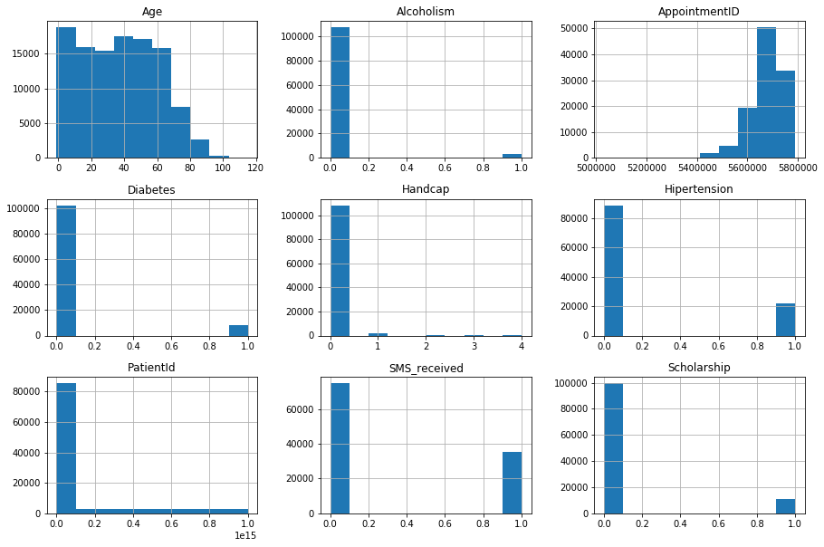

```python
df.hist(figsize = (15,10));
```

### Data Cleaning

**Rename columns with spelling mistakes and change columns names into lower case**

```python
# rename columns with spelling mistakes
# change column names to lower case

df.rename(columns = {'Hipertension': 'Hypertension',
                'Handcap': 'Handicap','No-show':'No_show'}, inplace = True)

df.columns = map(str.lower, df.columns)

df.head()
```

|  | patientid | appointmentid | gender | scheduledday | appointmentday | age | neighbourhood | scholarship | hypertension | diabetes | alcoholism | handicap | sms_received | no_show |
| --- | --- | --- | --- | --- | --- | --- | --- | --- | --- | --- | --- | --- | --- | --- |
| 0 | 2.987250e+13 | 5642903 | F | 2016-04-29T18:38:08Z | 2016-04-29T00:00:00Z | 62 | JARDIM DA PENHA | 0 | 1 | 0 | 0 | 0 | 0 | No |
| 1 | 5.589978e+14 | 5642503 | M | 2016-04-29T16:08:27Z | 2016-04-29T00:00:00Z | 56 | JARDIM DA PENHA | 0 | 0 | 0 | 0 | 0 | 0 | No |
| 2 | 4.262962e+12 | 5642549 | F | 2016-04-29T16:19:04Z | 2016-04-29T00:00:00Z | 62 | MATA DA PRAIA | 0 | 0 | 0 | 0 | 0 | 0 | No |
| 3 | 8.679512e+11 | 5642828 | F | 2016-04-29T17:29:31Z | 2016-04-29T00:00:00Z | 8 | PONTAL DE CAMBURI | 0 | 0 | 0 | 0 | 0 | 0 | No |
| 4 | 8.841186e+12 | 5642494 | F | 2016-04-29T16:07:23Z | 2016-04-29T00:00:00Z | 56 | JARDIM DA PENHA | 0 | 1 | 1 | 0 | 0 | 0 | No |

**Remove the outliers in age**

```python
# remove the outliers

df.drop(df[df.age <= 0].index, inplace = True)

df.drop(df[df.age > 100].index, inplace = True)
```

**Change type of patient id from string to integer**

```python
df['patientid'] = df['patientid'].astype('int64')
```

**Change appointment day and scheduled day into day of the week**

```python
# change type of day from string into datetime

df.appointmentday = df.appointmentday.apply(np.datetime64)
df.scheduledday   = df.scheduledday.apply(np.datetime64)

# add day of the week (weekday) into the dataframe

df['weekday'] = pd.to_datetime(df['appointmentday']).apply(lambda x: x.isoweekday())
```

```python
df.head()
```

|  | patientid | appointmentid | gender | scheduledday | appointmentday | age | neighbourhood | scholarship | hypertension | diabetes | alcoholism | handicap | sms_received | no_show | weekday |
| --- | --- | --- | --- | --- | --- | --- | --- | --- | --- | --- | --- | --- | --- | --- | --- |
| 0 | 29872499824296 | 5642903 | F | 2016-04-29 18:38:08 | 2016-04-29 | 62 | JARDIM DA PENHA | 0 | 1 | 0 | 0 | 0 | 0 | No | 5 |
| 1 | 558997776694438 | 5642503 | M | 2016-04-29 16:08:27 | 2016-04-29 | 56 | JARDIM DA PENHA | 0 | 0 | 0 | 0 | 0 | 0 | No | 5 |
| 2 | 4262962299951 | 5642549 | F | 2016-04-29 16:19:04 | 2016-04-29 | 62 | MATA DA PRAIA | 0 | 0 | 0 | 0 | 0 | 0 | No | 5 |
| 3 | 867951213174 | 5642828 | F | 2016-04-29 17:29:31 | 2016-04-29 | 8 | PONTAL DE CAMBURI | 0 | 0 | 0 | 0 | 0 | 0 | No | 5 |
| 4 | 8841186448183 | 5642494 | F | 2016-04-29 16:07:23 | 2016-04-29 | 56 | JARDIM DA PENHA | 0 | 1 | 1 | 0 | 0 | 0 | No | 5 |

**Change gender columns (female, male) to one column female (with 2 values: 1 means female and 0 means male)**

```python
# calculating the percentage of female

df.query('gender == "F"')['gender'].count()/df.shape[0]
```

```
0.6553654888764255
```

```python
# create the dummy variables female and male of gender

df[['female','male']] = pd.get_dummies(df['gender'])
df = df.drop(['gender', 'male'], axis = 1)
```

```python
# confirm the percentage of female

df.female.mean()
```

```
0.6553654888764255
```

**Change no_show columns (no, yes) to one column show_up to avoid misunderstandings (with 2 values: 1 means showing up and 0 means not showing up)**

```python
# calculating the percentage of patients who did not show up (with no_show equalling yes)

df.no_show.value_counts()['Yes']/df.shape[0]
```

```
0.2026266591886334
```

```python
# create dummy variable for show up and not show up at appointment

df[['show_up', 'not_show_up']] = pd.get_dummies(df['no_show'])
df = df.drop(['no_show'], axis = 1)
```

```python
# confirm the percentage of patients who did not show up

df.not_show_up.mean()
```

```
0.2026266591886334
```

```python
# confirm the percentage of patients who showed up

df.show_up.mean()
```

```
0.7973733408113666
```

**Calculate waiting time of each patient, which is the number of days from scheduled day to appointment day**

```python
df['waitingday'] = df["appointmentday"].sub(df["scheduledday"], axis=0)
df['waitingday'] = (df['waitingday']/np.timedelta64(1, 'D')).abs().round()
```

**Calculate the number of missing appointment of each patient**

```python
df['missed_appointment'] = df.groupby('patientid')['not_show_up'].apply(lambda x: x.cumsum())
```

```python
df.info()
```

```
<class 'pandas.core.frame.DataFrame'>
Int64Index: 106980 entries, 0 to 110526
Data columns (total 18 columns):
patientid             106980 non-null int64
appointmentid         106980 non-null int64
scheduledday          106980 non-null datetime64[ns]
appointmentday        106980 non-null datetime64[ns]
age                   106980 non-null int64
neighbourhood         106980 non-null object
scholarship           106980 non-null int64
hypertension          106980 non-null int64
diabetes              106980 non-null int64
alcoholism            106980 non-null int64
handicap              106980 non-null int64
sms_received          106980 non-null int64
weekday               106980 non-null int64
female                106980 non-null uint8
show_up               106980 non-null uint8
not_show_up           106980 non-null uint8
waitingday            106980 non-null float64
missed_appointment    106980 non-null uint64
dtypes: datetime64[ns](2), float64(1), int64(10), object(1), uint64(1), uint8(3)
memory usage: 13.4+ MB
```

```python
df.head(10)
```

|  | patientid | appointmentid | scheduledday | appointmentday | age | neighbourhood | scholarship | hypertension | diabetes | alcoholism | handicap | sms_received | weekday | female | show_up | not_show_up | waitingday | missed_appointment |
| --- | --- | --- | --- | --- | --- | --- | --- | --- | --- | --- | --- | --- | --- | --- | --- | --- | --- | --- |
| 0 | 29872499824296 | 5642903 | 2016-04-29 18:38:08 | 2016-04-29 | 62 | JARDIM DA PENHA | 0 | 1 | 0 | 0 | 0 | 0 | 5 | 1 | 1 | 0 | 1.0 | 0 |
| 1 | 558997776694438 | 5642503 | 2016-04-29 16:08:27 | 2016-04-29 | 56 | JARDIM DA PENHA | 0 | 0 | 0 | 0 | 0 | 0 | 5 | 0 | 1 | 0 | 1.0 | 0 |
| 2 | 4262962299951 | 5642549 | 2016-04-29 16:19:04 | 2016-04-29 | 62 | MATA DA PRAIA | 0 | 0 | 0 | 0 | 0 | 0 | 5 | 1 | 1 | 0 | 1.0 | 0 |
| 3 | 867951213174 | 5642828 | 2016-04-29 17:29:31 | 2016-04-29 | 8 | PONTAL DE CAMBURI | 0 | 0 | 0 | 0 | 0 | 0 | 5 | 1 | 1 | 0 | 1.0 | 0 |
| 4 | 8841186448183 | 5642494 | 2016-04-29 16:07:23 | 2016-04-29 | 56 | JARDIM DA PENHA | 0 | 1 | 1 | 0 | 0 | 0 | 5 | 1 | 1 | 0 | 1.0 | 0 |
| 5 | 95985133231274 | 5626772 | 2016-04-27 08:36:51 | 2016-04-29 | 76 | REPÚBLICA | 0 | 1 | 0 | 0 | 0 | 0 | 5 | 1 | 1 | 0 | 2.0 | 0 |
| 6 | 733688164476661 | 5630279 | 2016-04-27 15:05:12 | 2016-04-29 | 23 | GOIABEIRAS | 0 | 0 | 0 | 0 | 0 | 0 | 5 | 1 | 0 | 1 | 1.0 | 1 |
| 7 | 3449833394123 | 5630575 | 2016-04-27 15:39:58 | 2016-04-29 | 39 | GOIABEIRAS | 0 | 0 | 0 | 0 | 0 | 0 | 5 | 1 | 0 | 1 | 1.0 | 1 |
| 8 | 56394729949972 | 5638447 | 2016-04-29 08:02:16 | 2016-04-29 | 21 | ANDORINHAS | 0 | 0 | 0 | 0 | 0 | 0 | 5 | 1 | 1 | 0 | 0.0 | 0 |
| 9 | 78124564369297 | 5629123 | 2016-04-27 12:48:25 | 2016-04-29 | 19 | CONQUISTA | 0 | 0 | 0 | 0 | 0 | 0 | 5 | 1 | 1 | 0 | 1.0 | 0 |

## Exploratory Data Analysis

### Research Question 1. The difference in the probability of showing up between the groups of having scholarship, hypertension, alcoholism, diabetes, gender and receiving sms with the other groups

**Finding out the percentage of patients showing up at appointments**

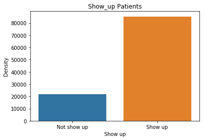

```
79.73733408113665% of patients showed up at the appointment
```

```python
ax = sns.countplot(x = df.show_up, data = df)
plt.title("Show_up Patients")
plt.xlabel('Show up')
plt.ylabel('Density')
ax.set_xticklabels(labels = ['Not show up', 'Show up'])
plt.show();

print('{}% of patients showed up at the appointment'.format(df.show_up.mean() * 100))
```

**Finding out whether showing up is related to scholarship, hypertension, alcoholism, diabetes, gender and receiving sms**

```python
columns = ['scholarship', 'hypertension', 'alcoholism', 'diabetes', 'sms_received', 'female']

for column in columns :
    print(df.groupby(column)['show_up'].mean())
```

```
scholarship
0    0.801333
1    0.762143
Name: show_up, dtype: float64
hypertension
0    0.789798
1    0.826972
Name: show_up, dtype: float64
alcoholism
0    0.797336
1    0.798512
Name: show_up, dtype: float64
diabetes
0    0.795561
1    0.819967
Name: show_up, dtype: float64
sms_received
0    0.832739
1    0.723340
Name: show_up, dtype: float64
female
0    0.799154
1    0.796437
Name: show_up, dtype: float64
```

Firstly, gender does not have any relationship with the showing up decision. It is apparent that the percentage of patients showing up at appointment of female and male is similar, equalling 80%. Looking at the above table, it can be seen that the percentage of patients showing up between the patients receiving scholarship and not receiving scholarship is not very different. The percentage of people who have scholarship coming to the appointments is slightly less than the group not receiving scholarship at 4%. In addition, the hypertension, alcoholism and diabetes also seem to not affect the decision of showing up at appointments of patients, as the difference between the group of having hypertension, alcoholism and diabetes and not having those features is very small, ranging from 1% to 4%.

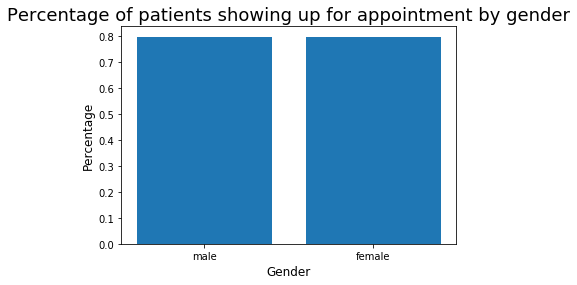

```python
# bar plot to plot the percentage of patients showing up at appointment by gender

plt.bar(x= ['male', 'female'], height = df.groupby('female')['show_up'].mean())
plt.xlabel('Gender' , fontsize = 12)
plt.ylabel('Percentage' , fontsize = 12)
plt.title('Percentage of patients showing up for appointment by gender',fontsize = 18);
```

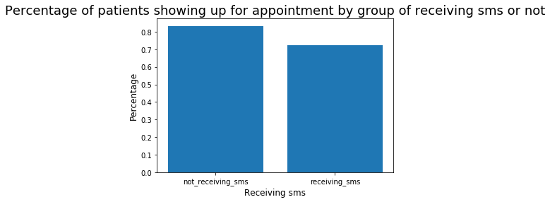

```python
# bar plot to plot the percentage of patients showing up at appointment by receiving sms or not

plt.bar(x= ['not_receiving_sms', 'receiving_sms'], height = df.groupby('sms_received')['show_up'].mean())
plt.xlabel('Receiving sms' , fontsize = 12)
plt.ylabel('Percentage' , fontsize = 12)
plt.title('Percentage of patients showing up for appointment by group of receiving sms or not',fontsize = 18);
```

There is only one special and interesting finding that the group receiving the sms tends to not show up than the group not receiving sms. In detailed, only 72% of the receiving_sms group show up for medical appointment, while this number of the group not receiving sms is 83%.

### Research Question 2. The relationship between showing up for appointment and the patient's age, number of waiting day, number of missing appointment, weekday of the appointment and the handicap situation.

**Firstly, we will define a function prob_col to calculate the probability of showing up for each group of patients. With this function, we can easily calculate the probability of showing up based on the condition in the column defined.**

```python
# define function prob_col to calculate the probability of showing up of the group in column

def prob_col(column):
    prob_col = pd.crosstab(index = df[column], columns = df['show_up']).reset_index()
    prob_col['show_up_prob'] = prob_col[1] / (prob_col[1] + prob_col[0])
    return(prob_col)
```

**With the function prob_col(column), we will plot the relationship between the showing up probability based on the age, waiting days, missing appointments, and handicap situation of the patient as well as the weekday of appointment.**

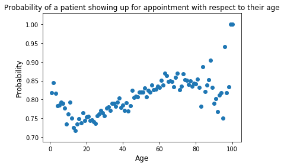

```python
# plot the relationship between age and probability of showing up

plt.scatter(x = prob_col('age')['age'], y = prob_col('age')['show_up_prob'])
plt.title('Probability of a patient showing up for appointment with respect to their age')
plt.xlabel('Age', fontsize = 12)
plt.ylabel('Probability', fontsize = 12)
plt.show();
```

It can be seen from the above scatter plot that the probability of showing up of a patient is related to his/her age. The percentage of showing up for medical appointments is higher when the age of the patients increases. For the age between 0 - 20 years old, the increase in age is related with a decrease in the probability of coming to the appointment. However, from the age of 20 up to 100, showing up probability increases in line with the age, as the two variables move on the same direction.

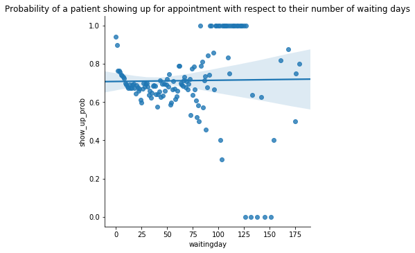

```python
# plot the relationship between number of waiting days and probability of showing up

sns.lmplot(data = prob_col('waitingday'), x = 'waitingday', y = 'show_up_prob', fit_reg = True)
plt.title('Probability of a patient showing up for appointment with respect to their number of waiting days')
plt.show();
```

The plot shows that the number of waiting days has no relation to the probability of showing up for medical appointment of the patients. The scatters spread out without any pattern.

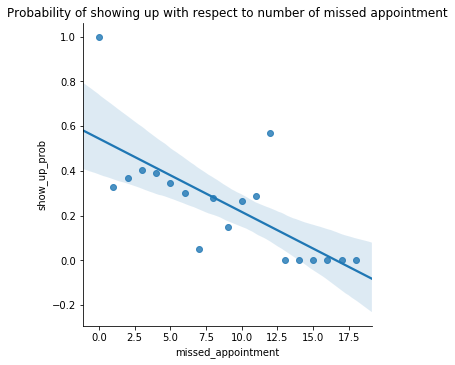

```python
# plot the relationship between number of missed appointment and probability of showing up

sns.lmplot(data = prob_col('missed_appointment'), x = 'missed_appointment', y = 'show_up_prob', fit_reg = True)
plt.title('Probability of showing up with respect to number of missed appointment')
plt.show();
```

The number of missed appointment can be used as a factor to predict whether a patient will come up at the appointment or not. In fact, the plot shows that a patient with low number of previously missed appointment tend to come up at the appointed day rather than the patient with high number of missed appointment. The probability of showing up and the number of missed appointment move has an opposite sign.

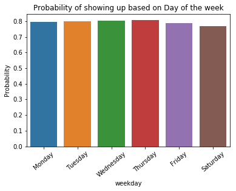

```python
# plot the relationship between day of the week of the appointment and probability of showing up

g = sns.barplot(data = prob_col('weekday'), x = 'weekday', y = 'show_up_prob')
plt.title('Probability of showing up based on Day of the week')
plt.ylabel('Probability')
g.set_xticklabels(labels = ['Monday', 'Tuesday', 'Wednesday', 'Thursday', 'Friday', 'Saturday'], rotation=40)
plt.show();
```

```python
prob_col('weekday')
```

| show_up | weekday | 0 | 1 | show_up_prob |
| --- | --- | --- | --- | --- |
| 0 | 1 | 4514 | 17387 | 0.793891 |
| 1 | 2 | 5024 | 19806 | 0.797664 |
| 2 | 3 | 4948 | 20142 | 0.802790 |
| 3 | 4 | 3242 | 13414 | 0.805355 |
| 4 | 5 | 3940 | 14524 | 0.786612 |
| 5 | 6 | 9 | 30 | 0.769231 |

The day of the week of the appointment seems to be irrelevant to the probability of showing up for appointment. Although the probability of showing up is slightly higher in the mid-week (from Tuesday to Thursday), and lower in weekend (Friday and Saturday), the gap is too small to be a predictor.

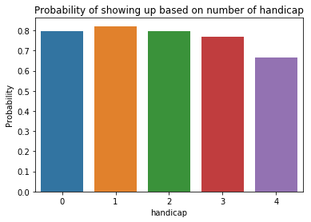

```python
# plot the relationship between the number of handicap of a patient and probability of showing up

sns.barplot(data = prob_col('handicap'), x = 'handicap', y = 'show_up_prob')
plt.title('Probability of showing up based on number of handicap')
plt.ylabel('Probability')
plt.show();
```

```python
prob_col('handicap')
```

| show_up | handicap | 0 | 1 | show_up_prob |
| --- | --- | --- | --- | --- |
| 0 | 0 | 21273 | 83471 | 0.796905 |
| 1 | 1 | 363 | 1674 | 0.821797 |
| 2 | 2 | 37 | 146 | 0.797814 |
| 3 | 3 | 3 | 10 | 0.769231 |
| 4 | 4 | 1 | 2 | 0.666667 |

The plot demonstrates that the number of handicap a patient presents is related to the probability of coming to the appointment. The increase in the number of handicap is related with a decrease in the probability of showing up. When the number of handicap increases from 1 to 4, the corresponding probability of showing up for appointment declines from 82% to 66%.

### Research Question 3. Is the neighbourhood of the patient a predictor for his/her showing up for the medical appointment?

Firstly, we will calculate the probability of showing up of each neighbourhood and sort the result in a descending order.

```python
# calculate the mean of showing up of each neighbourhood with groupby method and sort in a descending order
# by the probability of showing up

neighbor = df.groupby('neighbourhood').mean().sort_values(by = 'show_up', ascending = False)
```

```python
# defining top_10_neighbourhood with highest probability of showing up

neighbor['neighbourhood'] = neighbor.index.get_level_values(0)
top_10_neighbor = neighbor[0:10]
top_10_neighbor
```

| neighbourhood | patientid | appointmentid | age | scholarship | hypertension | diabetes | alcoholism | handicap | sms_received | weekday | female | show_up | not_show_up | waitingday | missed_appointment | neighbourhood |
| --- | --- | --- | --- | --- | --- | --- | --- | --- | --- | --- | --- | --- | --- | --- | --- | --- |
| PARQUE INDUSTRIAL | 8.255992e+12 | 5.663947e+06 | 17.000000 | 0.000000 | 0.000000 | 0.000000 | 0.000000 | 0.000000 | 0.000000 | 4.000000 | 1.000000 | 1.000000 | 0.000000 | 0.000000 | 0.000000 | PARQUE INDUSTRIAL |
| ILHA DO BOI | 3.528542e+14 | 5.691379e+06 | 48.628571 | 0.000000 | 0.114286 | 0.085714 | 0.000000 | 0.000000 | 0.200000 | 3.628571 | 0.542857 | 0.914286 | 0.085714 | 4.028571 | 0.085714 | ILHA DO BOI |
| AEROPORTO | 3.945965e+13 | 5.657990e+06 | 53.125000 | 0.000000 | 0.250000 | 0.000000 | 0.000000 | 0.000000 | 0.125000 | 3.250000 | 0.625000 | 0.875000 | 0.125000 | 14.250000 | 0.125000 | AEROPORTO |
| MÁRIO CYPRESTE | 1.395426e+14 | 5.701750e+06 | 37.275204 | 0.043597 | 0.149864 | 0.057221 | 0.038147 | 0.005450 | 0.228883 | 2.959128 | 0.514986 | 0.855586 | 0.144414 | 5.724796 | 0.318801 | MÁRIO CYPRESTE |
| SOLON BORGES | 1.600173e+14 | 5.664891e+06 | 46.502212 | 0.079646 | 0.061947 | 0.002212 | 0.000000 | 0.013274 | 0.382743 | 2.949115 | 0.752212 | 0.851770 | 0.148230 | 12.623894 | 0.236726 | SOLON BORGES |
| DE LOURDES | 1.343864e+14 | 5.668989e+06 | 45.703333 | 0.016667 | 0.353333 | 0.120000 | 0.050000 | 0.063333 | 0.323333 | 2.793333 | 0.640000 | 0.850000 | 0.150000 | 11.523333 | 0.246667 | DE LOURDES |
| DO CABRAL | 1.347762e+14 | 5.675746e+06 | 36.164179 | 0.180970 | 0.220149 | 0.067164 | 0.013060 | 0.029851 | 0.335821 | 2.751866 | 0.638060 | 0.843284 | 0.156716 | 9.591418 | 0.375000 | DO CABRAL |
| MORADA DE CAMBURI | 1.352447e+14 | 5.704550e+06 | 41.829787 | 0.000000 | 0.244681 | 0.138298 | 0.000000 | 0.031915 | 0.425532 | 3.074468 | 0.680851 | 0.840426 | 0.159574 | 7.361702 | 0.223404 | MORADA DE CAMBURI |
| SANTA MARTHA | 1.586113e+14 | 5.684395e+06 | 37.853009 | 0.144360 | 0.236764 | 0.091417 | 0.113121 | 0.039790 | 0.261427 | 2.827031 | 0.646169 | 0.839198 | 0.160802 | 8.411707 | 0.302861 | SANTA MARTHA |
| JARDIM DA PENHA | 1.478624e+14 | 5.673807e+06 | 45.290314 | 0.002856 | 0.260192 | 0.084913 | 0.006492 | 0.021553 | 0.367956 | 2.809660 | 0.688652 | 0.837185 | 0.162815 | 10.339392 | 0.298104 | JARDIM DA PENHA |

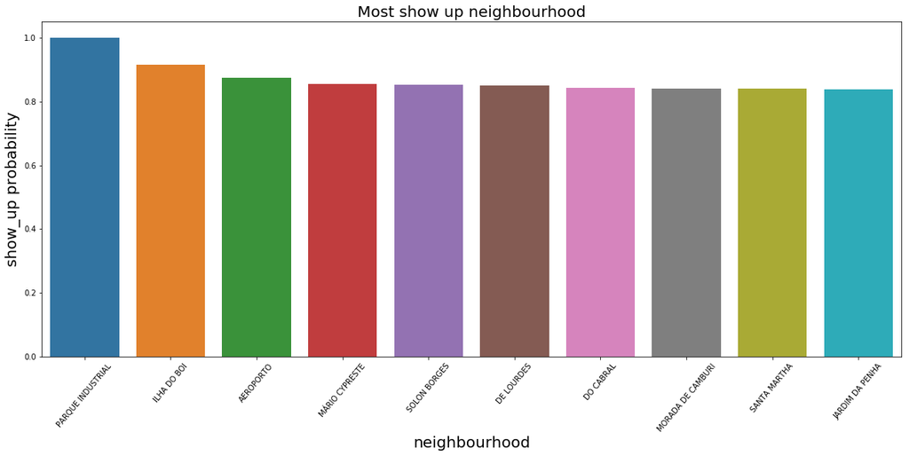

```python
# plot top 10 neighbourhood with the highest probability of showing up for appointment

plt.figure(figsize = (20,8))
g = sns.barplot(x = 'neighbourhood', y = 'show_up', data = top_10_neighbor)
plt.xlabel('neighbourhood', fontsize = 20)
plt.ylabel('show_up probability', fontsize = 20)
plt.title('Most show up neighbourhood', fontsize = 20)
g.set_xticklabels(g.get_xticklabels(), rotation=50);
```

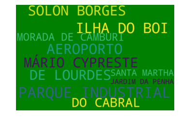

```python
top_10_neighbor = top_10_neighbor[['neighbourhood', 'show_up']]

d = {}
for a, x in top_10_neighbor.values:
    d[a] = x

import matplotlib.pyplot as plt

wordcloud = WordCloud(width = 600, height = 400, background_color = 'green')
wordcloud.generate_from_frequencies(frequencies=d)
plt.figure()
plt.imshow(wordcloud, interpolation="bilinear")
plt.axis("off")
plt.show()
```

From the bar plot of highest show_up probability neighbourhood, the patients from PARQUE INDUSTRIAL, ILHA DO BOI, AEROPORTO, MARIO CYPRESTE and SOLON BORGES are most potentially showing up for appointment.

```python
# defining 10_neighbourhood with the lowest probability of showing up
last_10_neighbor = neighbor[-10:]
last_10_neighbor
```

| neighbourhood | patientid | appointmentid | age | scholarship | hypertension | diabetes | alcoholism | handicap | sms_received | weekday | female | show_up | not_show_up | waitingday | missed_appointment | neighbourhood |
| --- | --- | --- | --- | --- | --- | --- | --- | --- | --- | --- | --- | --- | --- | --- | --- | --- |
| HORTO | 1.858613e+14 | 5.682746e+06 | 36.686747 | 0.036145 | 0.180723 | 0.084337 | 0.024096 | 0.114458 | 0.337349 | 2.855422 | 0.638554 | 0.771084 | 0.228916 | 6.289157 | 0.361446 | HORTO |
| ANDORINHAS | 1.476748e+14 | 5.677604e+06 | 37.066180 | 0.146508 | 0.267458 | 0.136467 | 0.023733 | 0.039708 | 0.254678 | 2.870379 | 0.657234 | 0.769055 | 0.230945 | 8.626654 | 0.556367 | ANDORINHAS |
| CARATOÍRA | 1.505933e+14 | 5.679279e+06 | 38.151065 | 0.183206 | 0.255123 | 0.079148 | 0.035356 | 0.022901 | 0.210928 | 3.053435 | 0.659703 | 0.764564 | 0.235436 | 8.736440 | 0.443953 | CARATOÍRA |
| ILHA DO PRÍNCIPE | 1.548170e+14 | 5.692259e+06 | 36.410891 | 0.257426 | 0.205671 | 0.054455 | 0.020252 | 0.014851 | 0.330783 | 2.834383 | 0.689919 | 0.763726 | 0.236274 | 5.671017 | 0.581008 | ILHA DO PRÍNCIPE |
| JESUS DE NAZARETH | 1.535286e+14 | 5.667883e+06 | 31.456786 | 0.099301 | 0.174329 | 0.064362 | 0.040088 | 0.019492 | 0.285031 | 2.929754 | 0.643251 | 0.751379 | 0.248621 | 11.515999 | 0.494299 | JESUS DE NAZARETH |
| ITARARÉ | 1.368204e+14 | 5.668968e+06 | 36.897714 | 0.091149 | 0.222450 | 0.078253 | 0.026377 | 0.022567 | 0.330598 | 2.758206 | 0.650059 | 0.736811 | 0.263189 | 10.819168 | 0.451055 | ITARARÉ |
| SANTA CLARA | 1.184271e+14 | 5.662152e+06 | 38.338710 | 0.058468 | 0.205645 | 0.064516 | 0.026210 | 0.026210 | 0.322581 | 2.832661 | 0.618952 | 0.733871 | 0.266129 | 11.667339 | 0.514113 | SANTA CLARA |
| SANTA CECÍLIA | 1.462554e+14 | 5.634217e+06 | 41.365688 | 0.056433 | 0.327314 | 0.067720 | 0.000000 | 0.029345 | 0.399549 | 2.735892 | 0.717833 | 0.729120 | 0.270880 | 21.731377 | 0.471783 | SANTA CECÍLIA |
| SANTOS DUMONT | 1.683180e+14 | 5.664084e+06 | 38.560448 | 0.188151 | 0.317854 | 0.112090 | 0.027222 | 0.012810 | 0.350681 | 2.792634 | 0.639712 | 0.708567 | 0.291433 | 11.794235 | 0.546037 | SANTOS DUMONT |
| ILHAS OCEÂNICAS DE TRINDADE | 3.895708e+12 | 5.583948e+06 | 54.500000 | 0.000000 | 0.000000 | 0.000000 | 0.000000 | 0.000000 | 0.000000 | 5.000000 | 1.000000 | 0.000000 | 1.000000 | 28.000000 | 1.000000 | ILHAS OCEÂNICAS DE TRINDADE |

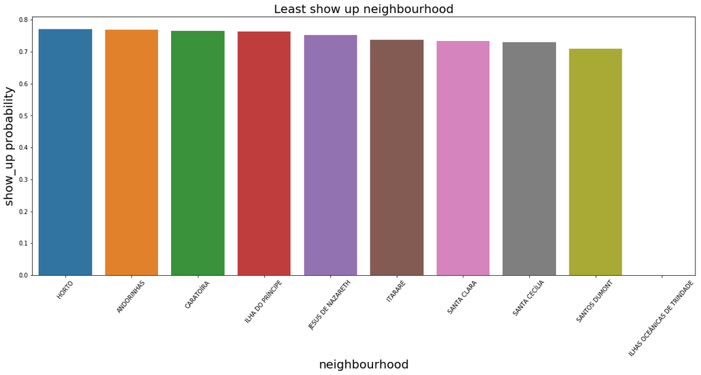

```python
# plot 10 neighbourhood with the lowest probability of showing up for appointment
plt.figure(figsize = (20,8))
g = sns.barplot(x = 'neighbourhood', y = 'show_up', data = last_10_neighbor)
plt.xlabel('neighbourhood', fontsize = 20)
plt.ylabel('show_up probability', fontsize = 20)
plt.title('Least show up neighbourhood', fontsize = 20)
g.set_xticklabels(g.get_xticklabels(), rotation=50);
```

From the bar plot of lowest show_up probability neighbourhood, the patients from the neighbourhood SANTA CLARA, SANTA CECÍLIA, SANTOS DUMONT and ILHAS OCEÂNICAS DE TRINDADE are the least likely to show up for medical appointment in Brazil.

## Conclusions

• Firstly, gender is not a predictor to expect a patient showing up or not since percentage of patients showing up at appointment of female and male is similar.

• The patients having scholarship are 4% less likely to show up for appointments than the group of not receiving scholarship.

• The hypertension, alcoholism and diabetes are not the factors to predict if a patient will show up at appointments.

• It is not necessary to send SMS to remind patients about their appointment since the group of patients receiving sms is 10% less likely to come to the appointment.

• Age of the patients is a good predictor to predict if a patient will show up for appointment since the probability of showing up of a patient is related to his/her age. The probability of showing up for medical appointments is correlated with the age of the patients in the same direction. From the age of 20 and above, showing up probability increases in line with the age.

• In addition, the number of missed appointment is another good factor to predict whether a patient will come up at the appointment or not. A patient with low number of previously missed appointment tend to come up at the appointed day rather than the patient with history of more missed appointment.

• The handicap situation of a patient is related to the probability of coming to the appointment. The increase in the number of handicap is related with a decrease in the probability of showing up. When the number of handicap increases from 1 to 4, the corresponding probability of showing up for appointment declines from 82% to 66%.

• The neighbourhood that a patient lives in also helps to predict if the patient shows up or not. For instance, the patients from PARQUE INDUSTRIAL, ILHA DO BOI, AEROPORTO, MARIO CYPRESTE and SOLON BORGES are most likely to show up for appointment whilst the patients from SANTA CLARA, SANTA CECÍLIA, SANTOS DUMONT and ILHAS OCEÂNICAS DE TRINDADE are the least likely to show up for medical appointment in Brazil.